# k-NN for classification

Introduction to statistical Learning

Pedro Delicado and Alex Sanchez

# Introduction

The **k-nearest neighbors (k-NN) classifier** is a non-parametric method used for classification tasks. Given a new observation $s$, the method assigns it the most frequent class among its $k$ nearest neighbors in the training set.

Mathematically, the probability estimate of belonging to class 1 at point $s$ is:

$$\hat{P}_1(s) = \frac{1}{k} \sum_{i \in N_k(s)} I(y_i = 1)$$

where: - $N_k(s)$ represents the set of $k$ nearest neighbors of $s$, - $I(y_i = 1)$ is an indicator function that equals 1 if the observation belongs to class 1 and 0 otherwise.

The predicted class is given by:

$$\hat{y}(s) = \arg\max_{c} \hat{P}_c(s)$$

where $\hat{P}_c(s)$ is the estimated probability of class $c$.

# Loading Data

We use a simulated dataset consisting of two-dimensional observations (features `x` and `y`) along with their class labels (BLUE / ORANGE).

```r
df.xy <- read.table(file="2clas2dim.csv", dec=".", sep=";", header = TRUE)
dim(df.xy)
```

```
## [1] 200   3
```

```r
df.xy[sample(1:nrow(df.xy),10),]
```

```
##               x          y  class
## 30   0.70572095 -0.4754421   BLUE
## 7    0.04709496 -0.1090832   BLUE
## 38   0.91652168  1.2163124   BLUE
## 127  0.99580853  2.6464520 ORANGE
## 78   2.40282542 -2.0761200   BLUE
## 22   2.97103281  0.9241729   BLUE
## 4    0.41747129 -0.3946581   BLUE
## 106 -0.77348016  1.5646892 ORANGE
## 103 -1.50795648  0.4493714 ORANGE
## 108  2.18399004  1.8823735 ORANGE
```

Now let’s see how Knn works for one point

```r
k <- 40
s <- 0
t <- 0
st <- c(s,t)

# Compute distances between (s,t) and all data points
d_st_xy <- as.matrix(dist(rbind(st, df.xy[,1:2])))[1, -1]

# Identify the k-th smallest distance
d_st_xy_k <- sort(d_st_xy, partial=k)[k]

# Identify the indices of the k nearest neighbors
N_st_k <- unname(which(d_st_xy <= d_st_xy_k))

# Compute probability estimate of class 'ORANGE' at (s,t)
(pr_1_k_st <- sum(df.xy[N_st_k,3] == 'ORANGE') / k)
```

```
## [1] 0.25
```

This code: 1. Defines a test point $(s,t) = (0,0)$. 2. Computes distances to all training points. 3. Selects the $k$ nearest neighbors. 4. Estimates the probability of class ‘ORANGE’ at $(s,t)$.

# Visualization of k-NN Neighborhood

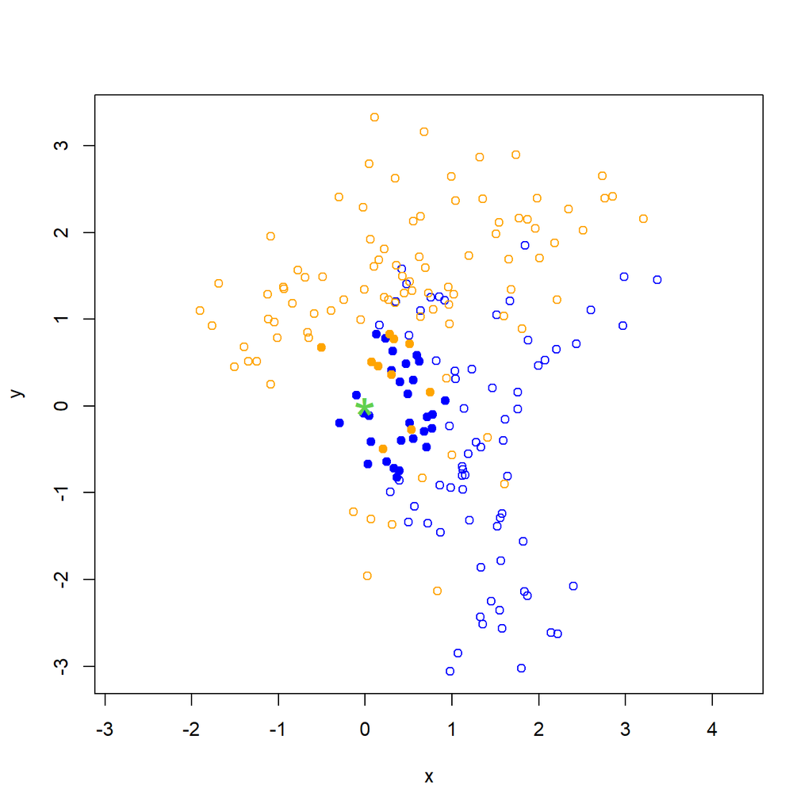

```r
plot(df.xy[,1:2], col=df.xy$class, pch=1 + 18 * ((1:200) %in% N_st_k), asp=1)
points(s, t, pch="*", col=3, cex=3)
```

This plot:

- Displays the dataset with colors representing different classes.
- Highlights the selected neighbors of the test point $(s,t)$.

# Generalizing the k-NN Classifier

The process can be encapsulated in a function.

```r
knn.class <- function(st, xy, group, k=3) {
  d_st_xy <- as.matrix(dist(rbind(st, xy)))[1, -1]
  d_st_xy_k <- sort(d_st_xy, partial=k)[k]
  N_st_k <- unname(which(d_st_xy <= d_st_xy_k))
  return(sum(group[N_st_k] == 1) / k)  # Probability of class 1
}
```

This function: - Computes distances between a test point `st` and all training points `xy`. - Identifies the $k$ nearest neighbors. - Estimates the probability of the test point belonging to class 1.

# Using the k-NN Classifier

```r
st <- c(0,0)
group <- as.numeric(df.xy[,3] == 'ORANGE')
knn.class(st=st, xy=df.xy[,1:2], group=group, k=40)
```

```
## [1] 0.25
```

This code predicts the class probability for $(0,0)$.

# Creating a Probability Map

```r
s <- t <- seq(-3.5, 3.5, by=.1)
ns <- length(s)
nt <- length(t)
hat_p <- matrix(0, nrow=ns, ncol=nt)

k <- 50

for (i in 1:ns) {
  for (j in 1:nt) {
    hat_p[i, j] <- knn.class(st=c(s[i], t[j]), xy=df.xy[,1:2], group=group, k=k)
  }
}
```

This block: - Defines a grid of test points in the feature space. - Computes class probabilities for each grid point using k-NN.

# Decision Boundary Visualization

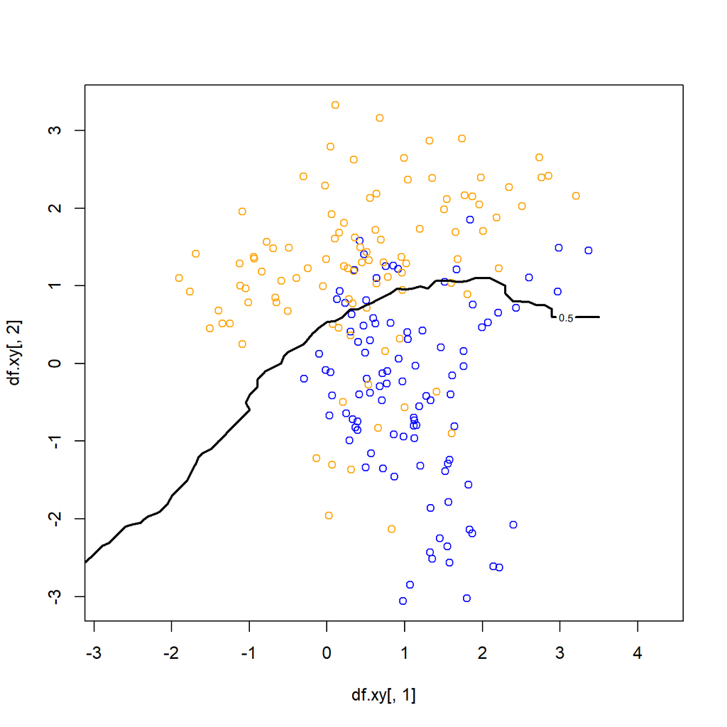

```r
plot(df.xy[,1], df.xy[,2], col=df.xy[,3], asp=1)
contour(s, t, hat_p, levels=.5, lwd=2, add=TRUE)
```

This plot: - Shows the decision boundary where the class probability is 0.5.

# Comparison with Logistic Regression

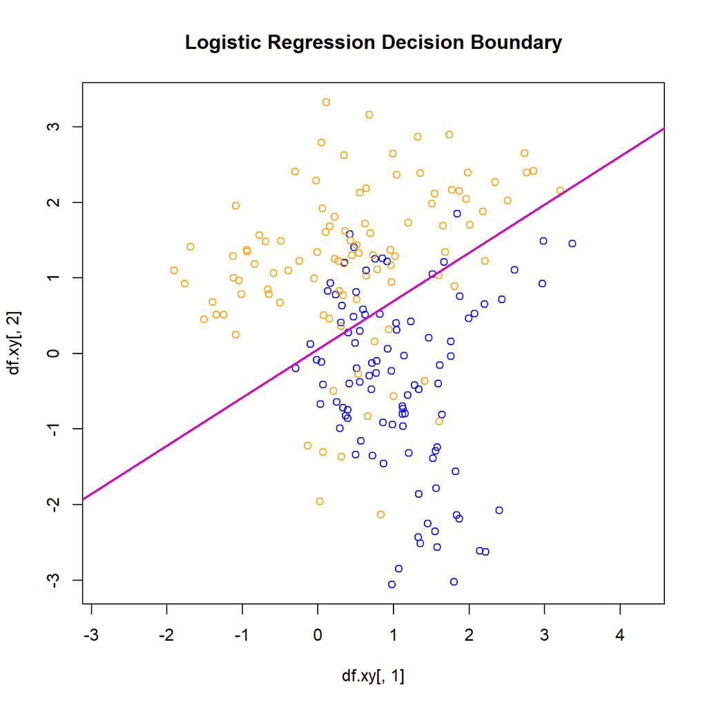

```r
# Fit logistic regression model
glm.class <- glm(group ~ x + y, data=df.xy, family=binomial)
b012 <- coefficients(glm.class)

# Create a new plot to ensure abline() has a base plot
plot(df.xy[,1], df.xy[,2], col=df.xy[,3], asp=1, main="Logistic Regression Decision Boundary")

# Add decision boundary line
abline(a = -b012[1]/b012[3], b = -b012[2]/b012[3], lwd=2, col=6)
```

This fits a logistic regression model and plots its decision boundary for comparison.

# K-NN classifier is also a flexible classifier

We observe that: - **k-NN produces a flexible decision boundary**, adapting to the local structure of the data. - **Larger $k$ values create smoother boundaries**, reducing variance. - **Logistic regression assumes a linear boundary**, which may not be suitable for non-linear patterns.